# Dates

Robert W Schlegel

2017-12-21

# Introduction

This script covers some of the more common issues we may face while dealing with dates.

```r
# Load libraries
library(tidyverse)
library(lubridate)
library(zoo)

# Load data
sad_dates <- read.csv("../data/sad_dates.csv")
```

# Date details

Look at strip time format for guidance

```r
?strptime
```

Check the local time zone

```r
Sys.timezone(location = TRUE)
```

```
R> [1] "Africa/Mbabane"
```

# Creating daily dates

Create date columns out of the mangled date data we have loaded.

```r
# Create good date column
new_dates <- sad_dates %>%
  mutate(new_good = as.Date(good))

# Correct bad date column
new_dates <- new_dates %>%
  mutate(new_bad = as.Date(bad, format = "%m/%d/%y"))

# Correct ugly date column
new_dates <- new_dates %>%
  mutate(new_ugly = seq(as.Date("1998-01-13"), as.Date("1998-01-21"), by = "day"))
```

# Creating hourly dates

If we want to create date values out of data that have hourly values (or smaller), we must create ‘POSIXct’ valus because ‘Date’ values may not have a finer temporal resolution than one day.

```r
# Correcting good time stamps with hours
new_dates <- new_dates %>%
  mutate(new_good_hours = as.POSIXct(good_hours, tz = "Africa/Mbabane"))


# Correcting bad time stamps with hours
new_dates <- new_dates %>%
  mutate(new_bad_hours = as.POSIXct(bad_hours, format = "%Y-%m-%d %I:%M:%S %p", tz = "Africa/Mbabane"))


# Correcting bad time stamps with hours
new_dates <- new_dates %>%
  mutate(new_ugly_hours = seq(as.POSIXct("1998-01-13 09:00:00", tz = "Africa/Mbabane"),
                              as.POSIXct("1998-01-13 17:00:00", tz = "Africa/Mbabane"), by = "hour"))
```

But shouldn’t there be a function that loads dates correctly?

# Importing dates in one step

Why yes, yes there is. `read_csv()` is the way to go.

```r
smart_dates <- read_csv("../data/sad_dates.csv")
```

But why does it matter that we correct the values to dates? For starters, it affects the way our plots look/work. Let’s create some random numbers for plotting and see how these compare against our date values when we create figures.

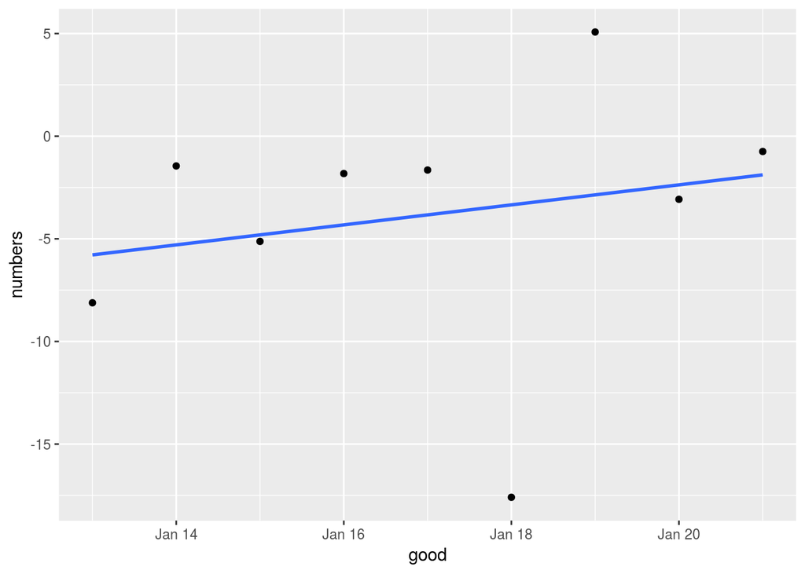

```r
# Generate random number
smart_dates$numbers <- rnorm(9, 2, 10)

# Scatterplot with correct dates
ggplot(smart_dates, aes(x = good, y = numbers)) +
  geom_point() +
  geom_smooth(method = "lm", se = F)
```

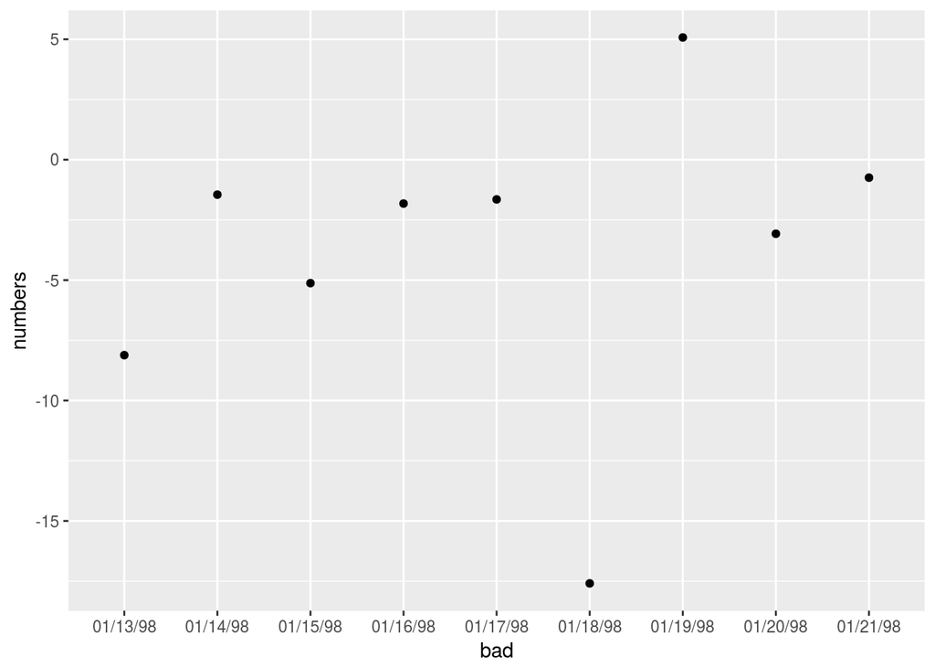

```r
# Scatterplot with incorrect dates
ggplot(smart_dates, aes(x = bad, y = numbers)) +
  geom_point() +
  geom_smooth(method = "lm", se = F)
```

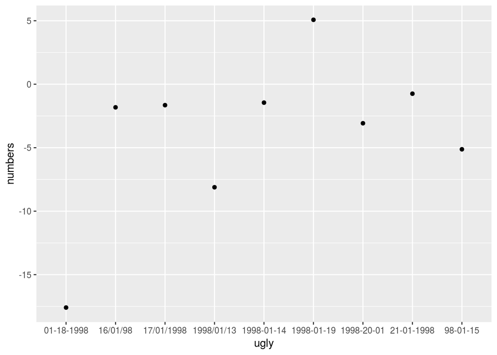

```r
# OR
ggplot(smart_dates, aes(x = ugly, y = numbers)) +
  geom_point() +
  geom_smooth(method = "lm", se = F)
```

If the dates are formatted correctly it also allows us to do schnazy things with the data.

```r
smart_dates$good[4]+32
```

```
R> [1] "1998-02-17"
```

```r
smart_dates$good[9]-smart_dates$good[3]
```

```
R> Time difference of 6 days
```

```r
as.Date(smart_dates$good[9]:smart_dates$good[3])
```

```
R> [1] "1998-01-21" "1998-01-20" "1998-01-19" "1998-01-18" "1998-01-17"
R> [6] "1998-01-16" "1998-01-15"
```

```r
smart_dates$good[9]-10247
```

```
R> [1] "1970-01-01"
```